```python
import sqlite3
import pandas as pd
import matplotlib.pyplot as plt
```

```python
sqlite_file = 'lahman2014.sqlite'
conn = sqlite3.connect(sqlite_file)

salary_query = "SELECT yearID, teamID, sum(salary) as total_payroll FROM Salaries GROUP BY yearID, teamID"

team_salaries = pd.read_sql(salary_query, conn)
```

# PART ONE

```python
pay_wins_query = "SELECT yearID, teamID, G, W FROM Teams GROUP BY yearID, teamID"
paywins_table = pd.read_sql(pay_wins_query, conn)
paywins_table.head()
```

|  | yearID | teamID | G | W |
| --- | --- | --- | --- | --- |
| 0 | 1871 | BS1 | 31 | 20 |
| 1 | 1871 | CH1 | 28 | 19 |
| 2 | 1871 | CL1 | 29 | 10 |
| 3 | 1871 | FW1 | 19 | 7 |
| 4 | 1871 | NY2 | 33 | 16 |

```python
# Getting rid of rows withe year < 1985

i=0

for row in paywins_table['yearID']:
    if int(row) < 1985:
        paywins_table = paywins_table.drop(paywins_table.index[i])
        i = i-1
    i = i + 1

i=0

for row in team_salaries['yearID']:
    if int(row) < 1985:
        team_salaries = team_salaries.drop(paywins_table.index[i])
        i = i-1
    i = i + 1

team_salaries.reset_index(drop=True, inplace=True)
paywins_table.reset_index(drop=True, inplace=True)
```

```python
team_salaries.head()
```

[output not shown]

```python
paywins_table.head()
```

[output not shown]

```python
# Combining Team and Year

i = 0
year_team = []
for r in paywins_table['yearID']:
    year_team.insert(i, str(paywins_table['teamID'][i]) + " " + str(paywins_table['yearID'][i]))
    i = i+1

paywins_table['team-year'] = year_team


i = 0
year_team = []
for r in team_salaries['yearID']:
    year_team.insert(i, str(team_salaries['teamID'][i]) + " " + str(team_salaries['yearID'][i]))
    i = i+1

team_salaries['team-year'] = year_team
```

# PART 1 CONTINUED: Win Percentage Calculation

```python
# PART 1 CONTINUED: Win Percentage Calculation
teamlist = []
paylist = []

for t in team_salaries['team-year']:
    teamlist.append(t)
for p in paywins_table['team-year']:
    paylist.append(p)


# the three lists are for the new columns for the updated table
# 1) Pay, 2) Team and year, 3) win percentage
list1 = []
list2 = []
list3 = []
list4 = []
list5 = []

unmatched = []
wins_list = []



# Doing the win percentage calculation
for i in range(len(paywins_table['W'])):
        wins_list.append((paywins_table['W'][i] / paywins_table['G'][i]) * 100)


k = 0
i = 0
for p in team_salaries['team-year']:
#     print(team_salaries['team-year'])

    if p in paylist:


        list1.append(team_salaries['total_payroll'][i])

        list2.insert(i, p)
        list3.insert(i, wins_list[i])
        list4.insert(i, paywins_table['yearID'][i])
        list5.insert(i, paywins_table['teamID'][i])
        i = i + 1

    else:
        unmatched.insert(k, p)
        k = k+1





new_table = pd.DataFrame(list1, columns = ["total_payroll"])

new_table['team-year'] = list2
new_table['Winning_Percentage'] = list3
new_table['yearID'] = list4
new_table['teamID'] = list5
```

```python
# Two rows from the team salaries table are not in the table with the wins and games
print(unmatched)
```

```
['NYM 2014', 'SFG 2014']
```

```python
# END OF PART 1 ---------------------------------------------------


new_table['yearID'] = paywins_table['yearID']
```

# PART TWO

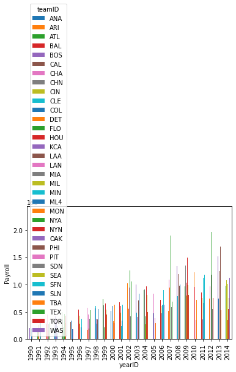

```python
# PART 2 -------------------

table_2 = new_table[new_table['yearID'] >=1990]

table_2.pivot(index = 'yearID', columns= 'teamID', values='total_payroll').plot(ylabel = 'Payroll', kind= 'bar' )
```

# Part Two: Question 1

# Question 1 (9 pts) # What statements can you make about the distribution of payrolls conditioned # on time based on these plots? Remember you can make statements # in terms of central tendency, spread, etc. # It seams that the average salary for teams have been inscreasing in these 24 years.

# PART 2: PROBLEM 3

```python
#PART 2: PROBLEM 3
sum = 0
paylist = []
i = 0
avglist = []
years = []

for x in table_2['total_payroll']:
    paylist.append(x)
    i = i + 1

k= 0
for year in range(1990, 2015):
    i = 0
    years.append(year)

    sum = 0
    for y in table_2['yearID']:
        if int(y) == year:
            sum = sum + paylist[k]
            k=k+1
            i = i+1
    avg = sum / (i)
#     print(str(year) + " " + str(avg))

    avglist.append(avg)

mean_pay = pd.DataFrame(avglist, columns = ['mean pay'])
mean_pay['yearID'] = years
mean_pay # table with average pay each year
```

|  | mean pay | yearID |
| --- | --- | --- |
| 0 | 1.707235e+07 | 1990 |
| 1 | 2.357879e+07 | 1991 |
| 2 | 3.098244e+07 | 1992 |
| 3 | 3.220500e+07 | 1993 |
| 4 | 3.313701e+07 | 1994 |
| 5 | 3.398105e+07 | 1995 |
| 6 | 3.417798e+07 | 1996 |
| 7 | 4.026021e+07 | 1997 |
| 8 | 4.260943e+07 | 1998 |
| 9 | 4.980762e+07 | 1999 |
| 10 | 5.553784e+07 | 2000 |
| 11 | 6.535544e+07 | 2001 |
| 12 | 6.746925e+07 | 2002 |
| 13 | 7.094207e+07 | 2003 |
| 14 | 6.902220e+07 | 2004 |
| 15 | 7.295711e+07 | 2005 |
| 16 | 7.738242e+07 | 2006 |
| 17 | 8.255630e+07 | 2007 |
| 18 | 8.949529e+07 | 2008 |
| 19 | 8.882423e+07 | 2009 |
| 20 | 9.071200e+07 | 2010 |
| 21 | 9.281684e+07 | 2011 |
| 22 | 9.775804e+07 | 2012 |
| 23 | 1.011509e+08 | 2013 |
| 24 | 9.834713e+07 | 2014 |

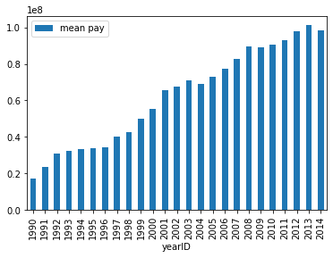

```python
#PART 2: PROBLEM 3 - Graph showing the mean pay for each year
mean_pay.plot(x = 'yearID', y='mean pay', kind= 'bar' )
```

# PART 2 PROBLEM 4 ------------------------------------------

--------------------------------------------------------------------------------------------------------------------------- # Part 2 Problem 4: Write code to discretize year into five time periods (you can use pandas.cut to accomplish this) and then make a scatterplot showing mean winning percentage (y-axis) vs. mean payroll (x-axis) for each of the five time periods. You could add a regression line (using, e.g., NumPy's polyfit) in each scatter plot to ease interpretation.

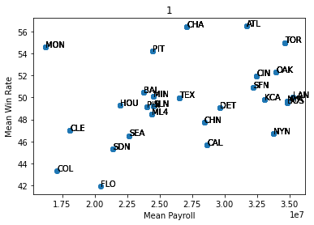

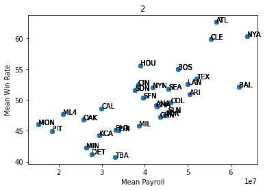

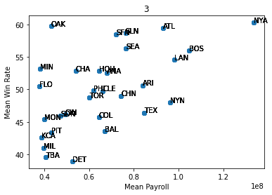

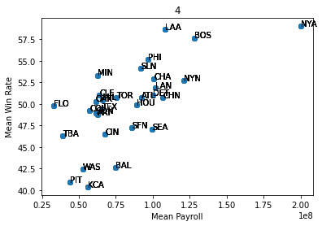

```
posx and posy should be finite values
posx and posy should be finite values
posx and posy should be finite values
posx and posy should be finite values
```

[figure not shown]

```python
#--------------------------------------------------------------------------------------------------
# First Time Period 1990 - 1994
salary_period1 = team_salaries[(team_salaries['yearID'] >= 1990) & (team_salaries['yearID'] <=1994)]
salary_period1.reset_index(drop=True, inplace=True)

team_wins1 = table_2[(table_2['yearID'] >=1990) & (table_2['yearID'] <=1994)]
team_wins1.reset_index(drop=True, inplace=True)

#for the means
mean_salaries1 = []
mean_wins1 = []

# teams
just_teams1 = []
for t in salary_period1['teamID']:
    just_teams1.append(t)

#
for t in just_teams1:
    mean_salaries1.append(salary_period1.total_payroll[salary_period1['teamID'] == t].mean())
    mean_wins1.append(team_wins1.Winning_Percentage[team_wins1['teamID'] == t].mean())



plt.scatter(mean_salaries1, mean_wins1)
[plt.text(x = mean_salaries1[x], y = mean_wins1[x], s = just_teams1[x]) for x in range(len(just_teams1))]
plt.xlabel('Mean Payroll')
plt.ylabel('Mean Win Rate')
plt.title('1')
plt.show()

#-----------------------------------------------------------------------------------
# Second time period
salary_period2 = team_salaries[(team_salaries['yearID'] >= 1995) & (team_salaries['yearID'] <=1999)]
salary_period2.reset_index(drop=True, inplace=True)

team_wins2 = table_2[(table_2['yearID'] >=1995) & (table_2['yearID'] <=1999)]
team_wins2.reset_index(drop=True, inplace=True)

df = pd.DataFrame([],  columns = [])
mean_salaries2 = []
mean_wins2 = []

just_teams2 = []
for t in team_wins2['teamID']:
    just_teams2.append(t)

for t in just_teams2:
    mean_salaries2.append(salary_period2.total_payroll[salary_period2['teamID'] == t].mean())
    mean_wins2.append(team_wins2.Winning_Percentage[team_wins2['teamID'] == t].mean())


plt.scatter(mean_salaries2, mean_wins2)
[plt.text(x = mean_salaries2[x], y = mean_wins2[x], s = just_teams2[x]) for x in range(len(just_teams2))]
plt.xlabel('Mean Payroll')
plt.ylabel('Mean Win Rate')
plt.title('2')
plt.show()
#----------------------------------------------------------------------------------------------------
# Third time period (2000 -2004)
salary_period3 = team_salaries[(team_salaries['yearID'] >= 2000) & (team_salaries['yearID'] <=2004)]
salary_period3.reset_index(drop=True, inplace=True)

team_wins3 = table_2[(table_2['yearID'] >= 2000) & (table_2['yearID'] <= 2004)]
team_wins3.reset_index(drop=True, inplace=True)

df3 = pd.DataFrame([],  columns = [])
mean_salaries3 = []
mean_wins3 = []


just_teams3 = []
for t in salary_period3['teamID']:
    just_teams3.append(t)

for t in just_teams3:
    mean_salaries3.append(salary_period3.total_payroll[salary_period3['teamID'] == t].mean())
    mean_wins3.append(team_wins3.Winning_Percentage[team_wins3['teamID'] == t].mean())


plt.scatter(mean_salaries3, mean_wins3)
[plt.text(x = mean_salaries3[x], y = mean_wins3[x], s = just_teams3[x]) for x in range(len(just_teams3))]
plt.xlabel('Mean Payroll')
plt.ylabel('Mean Win Rate')
plt.title('3')
plt.show()

#--------------------------------------------------------------------------------------------
# Fouth time period (2005 -2009)
salary_period4 = team_salaries[(team_salaries['yearID'] >= 2005) & (team_salaries['yearID'] <=2009)]
salary_period4.reset_index(drop=True, inplace=True)

team_wins4 = table_2[(table_2['yearID'] >= 2005) & (table_2['yearID'] <= 2009)]
team_wins4.reset_index(drop=True, inplace=True)

mean_salaries4 = []
mean_wins4 = []

just_teams4 = []
for t in salary_period4['teamID']:
    just_teams4.append(t)



for t in just_teams4:
    mean_salaries4.append(salary_period4.total_payroll[salary_period4['teamID'] == t].mean())
    mean_wins4.append(team_wins4.Winning_Percentage[team_wins4['teamID'] == t].mean())


plt.scatter(mean_salaries4, mean_wins4)

# df.plot.scatter(x = 'Wins', y='Salary')
[plt.text(x = mean_salaries4[x], y = mean_wins4[x], s = just_teams4[x]) for x in range(len(just_teams4))]
plt.xlabel('Mean Payroll')
plt.ylabel('Mean Win Rate')
plt.title('4')
plt.show()

#--------------------------------------------------------------------------------------------------------------

# Fifth time period (2010 -2014)----------------------------------------------------------------------------------
salary_period5 = team_salaries[(team_salaries.yearID >= 2010) & (team_salaries.yearID <=2014)]
salary_period5.reset_index(drop=True, inplace=True)

team_wins5 = table_2[(table_2.yearID >= 2010) & (table_2.yearID <= 2014)]
team_wins5.reset_index(drop=True, inplace=True)

df5 = pd.DataFrame([],  columns = [])
mean_salaries5 = []
mean_wins5 = []

just_teams5 = []
# just_teams5 = list(set(salary_period5['teamID']))
for t in salary_period5['teamID']:
    just_teams5.append(t)



for t in just_teams5:
    mean_salaries5.append(salary_period5.total_payroll[salary_period5['teamID'] == t].mean())
    mean_wins5.append(team_wins5.Winning_Percentage[team_wins5['teamID'] == t].mean())

plt.scatter(mean_salaries5, mean_wins5)

# df.plot.scatter(x = 'Wins', y='Salary')
[plt.text(x = mean_salaries5[x], y = mean_wins5[x], s = just_teams5[x]) for x in range(len(just_teams5))]
plt.xlabel('Mean Payroll')
plt.ylabel('Mean Win Rate')
plt.title('2010-2014')
plt.show()
```

Part 2 Question 2: What can you say about team payrolls across these periods? Are there any teams that standout as being particularly good at paying for wins across these time periods? What can you say about the Oakland A's spending efficiency across these time periods (labeling points in the scatterplot can help interpretation). - It seems that the NYA had a low win rate but a high payroll, and later on had the highest win rate and highest payroll. It looks like this team invested in players that can be trusted to help bring in more wins - In earlier time periods it did not look like there was any correlation between payroll and win rate, but as the years went by there seemed to be more and more of a correlation. - Oakland's was interesting because of how much it moved around. In the earlier times they had higher pay rates and higher win rates. Later, between 2000 and 2014 they have a low payroll but very high win rate.

# PART 3 : Problem 5------------------------------

```python
# PART 3 PROBLEM 5 --------------------------------

mean = 0
lst2 = []
stds = []


avg = 0

for y in range(1985,2015):

    tmean = new_table.total_payroll[new_table['yearID'] == y].mean() # payroll mean
    st = new_table.total_payroll[new_table['yearID'] == y].std()      # payroll standard dev


    lst = new_table.total_payroll[new_table['yearID'] == y]   # total payrolls in year
#     for l in lst:
#         lst2.append(l)


    for x in lst:
        stds.append((x - tmean) /  st)


stds

new_table['standard_dev'] = stds
```

```python
new_table[new_table['yearID'] >=1990]
```

|  | total_payroll | team-year | Winning_Percentage | yearID | teamID | standard_dev |
| --- | --- | --- | --- | --- | --- | --- |
| 130 | 14555501.0 | ATL 1990 | 40.123457 | 1990 | ATL | -0.667275 |
| 131 | 9680084.0 | BAL 1990 | 47.204969 | 1990 | BAL | -1.959861 |
| 132 | 20558333.0 | BOS 1990 | 54.320988 | 1990 | BOS | 0.924213 |
| 133 | 21720000.0 | CAL 1990 | 49.382716 | 1990 | CAL | 1.232198 |
| 134 | 9491500.0 | CHA 1990 | 58.024691 | 1990 | CHA | -2.009859 |
| ... | ... | ... | ... | ... | ... | ... |
| 853 | 143510167.0 | SLN 2014 | 55.555556 | 2014 | SLN | 0.966575 |
| 854 | 20000000.0 | TBA 2014 | 47.530864 | 2014 | TBA | -1.676778 |
| 855 | 120693000.0 | TEX 2014 | 41.358025 | 2014 | TEX | 0.478244 |
| 856 | 72689100.0 | TOR 2014 | 51.234568 | 2014 | TOR | -0.549131 |
| 857 | 112255059.0 | WAS 2014 | 59.259259 | 2014 | WAS | 0.297656 |

728 rows × 6 columns

# PART 3 PROBLEM 6 ----------------------

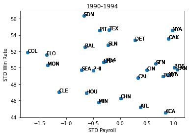

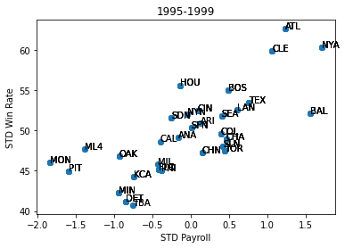

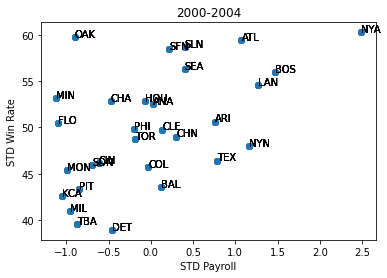

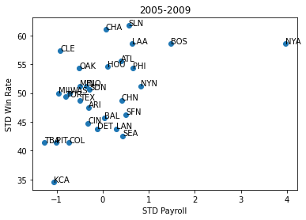

[output not shown]

[figure not shown]

```python
# First Time Period 1990 - 1994
ttable1 = new_table[(new_table['yearID'] >= 1990) & (new_table['yearID'] <=1994)]
ttable1.reset_index(drop=True, inplace=True)

twins1 = new_table[(new_table['yearID'] >=1990) & (new_table['yearID'] <=1994)]
twins1.reset_index(drop=True, inplace=True)

#for the means
std_salaries1 = []
std_wins1 = []

# teams
just_teams1 = []
for t in ttable1['teamID']:
    just_teams1.append(t)

#
for t in just_teams1:
    std_salaries1.append(ttable1.standard_dev[ttable1['teamID'] == t].mean())
    std_wins1.append(ttable1.Winning_Percentage[ttable2['teamID'] == t].mean())



plt.scatter(std_salaries1, std_wins1)
[plt.text(x = std_salaries1[x], y = std_wins1[x], s = just_teams1[x]) for x in range(len(just_teams1))]
plt.xlabel('STD Payroll')
plt.ylabel('STD Win Rate')
plt.title('1990-1994')
plt.show()

# SECOND Time Period 1995 - 1999------------------------------------------------
ttable2 = new_table[(new_table['yearID'] >= 1995) & (new_table['yearID'] <=1999)]
ttable2.reset_index(drop=True, inplace=True)


#for the means
std_salaries2 = []
std_wins2 = []

# teams
just_teams2 = []
for t in ttable2['teamID']:
    just_teams2.append(t)
#
for t in just_teams2:
    std_salaries2.append(ttable2.standard_dev[ttable2['teamID'] == t].mean())
    std_wins2.append(ttable2.Winning_Percentage[team_wins2['teamID'] == t].mean())



plt.scatter(std_salaries2, std_wins2)
[plt.text(x = std_salaries2[x], y = std_wins2[x], s = just_teams2[x]) for x in range(len(just_teams2))]
plt.xlabel('STD Payroll')
plt.ylabel('STD Win Rate')
plt.title('1995-1999')
plt.show()

# THIRD Time Period 2000 - 2004------------------------------------------
ttable3 = new_table[(new_table['yearID'] >= 2000) & (new_table['yearID'] <=2004)]
ttable3.reset_index(drop=True, inplace=True)


#for the means
std_salaries3 = []
std_wins3 = []

# teams
just_teams3 = []
for t in ttable3['teamID']:
    just_teams3.append(t)
#
for t in just_teams3:
    std_salaries3.append(ttable3.standard_dev[ttable3['teamID'] == t].mean())
    std_wins3.append(ttable3.Winning_Percentage[ttable3['teamID'] == t].mean())



plt.scatter(std_salaries3, std_wins3)
[plt.text(x = std_salaries3[x], y = std_wins3[x], s = just_teams3[x]) for x in range(len(just_teams3))]
plt.xlabel('STD Payroll')
plt.ylabel('STD Win Rate')
plt.title('2000-2004')
plt.show()

# FOURTH Time Period 2005 - 2009----------------------------------------------------------------------
ttable4 = new_table[(new_table['yearID'] >= 2005) & (new_table['yearID'] <=2005)]
ttable4.reset_index(drop=True, inplace=True)


#for the means
std_salaries4 = []
std_wins4 = []

# teams
just_teams4 = []
for t in ttable4['teamID']:
    just_teams4.append(t)
#
for t in just_teams4:
    std_salaries4.append(ttable4.standard_dev[ttable4['teamID'] == t].mean())
    std_wins4.append(ttable4.Winning_Percentage[ttable4['teamID'] == t].mean())



plt.scatter(std_salaries4, std_wins4)
[plt.text(x = std_salaries4[x], y = std_wins4[x], s = just_teams4[x]) for x in range(len(just_teams4))]
plt.xlabel('STD Payroll')
plt.ylabel('STD Win Rate')
plt.title('2005-2009')
plt.show()


# FIFTH Time Period 2010 - 2014---------------------------------------------------------------------------------
ttable5 = new_table[(new_table['yearID'] >= 2010) & (new_table['yearID'] <=2014)]
ttable5.reset_index(drop=True, inplace=True)


#for the means
std_salaries5 = []
std_wins5 = []

# teams
just_teams5 = []
for t in ttable5['teamID']:
    just_teams5.append(t)
#
for t in just_teams5:
    std_salaries5.append(ttable4.standard_dev[ttable5['teamID'] == t].mean())
    std_wins5.append(ttable4.Winning_Percentage[ttable5['teamID'] == t].mean())



plt.scatter(std_salaries5, std_wins5)
[plt.text(x = std_salaries5[x], y = std_wins5[x], s = just_teams5[x]) for x in range(len(just_teams5))]
plt.xlabel('STD Payrol')
plt.ylabel('STD Win Rate')
plt.title('2010-2014')
plt.show()
```

# PART 3 QUESTION 3 --------------------------

# Part 3 Problem 7----------------

[figure not shown]

```python
plt.xlabel('Win Percent')
plt.ylabel('Standardized Payroll')
plt.scatter(new_table['standard_dev'], new_table['Winning_Percentage'] )
```

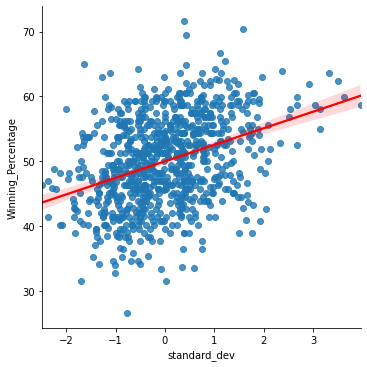

```python
import seaborn as sns

sns.lmplot(x="standard_dev", y = "Winning_Percentage", data=new_table, fit_reg = True , line_kws = {'color': 'red'})
```

```python
expected_wins = []
for s in new_table['standard_dev']:
    expected_wins.append(50 + 2.5 * s)
new_table['expected_wins'] = expected_wins
```

# Part 3 Problem 8

```python
efficiency = []
for i in range(len(new_table['Winning_Percentage'])):
    efficiency.append(new_table['Winning_Percentage'][i] - new_table['expected_wins'][i])

new_table['efficiency'] = efficiency
```

```python
new_table.head()
```

|  | total_payroll | team-year | Winning_Percentage | yearID | teamID | standard_dev | expected_wins | efficiency |
| --- | --- | --- | --- | --- | --- | --- | --- | --- |
| 0 | 14807000.0 | ATL 1985 | 40.740741 | 1985 | ATL | 1.914905 | 54.787263 | -14.046522 |
| 1 | 11560712.0 | BAL 1985 | 51.552795 | 1985 | BAL | 0.601068 | 51.502671 | 0.050124 |
| 2 | 10897560.0 | BOS 1985 | 49.693252 | 1985 | BOS | 0.332678 | 50.831694 | -1.138442 |
| 3 | 14427894.0 | CAL 1985 | 55.555556 | 1985 | CAL | 1.761474 | 54.403684 | 1.151872 |
| 4 | 9846178.0 | CHA 1985 | 52.147239 | 1985 | CHA | -0.092838 | 49.767906 | 2.379333 |

```python
te = []
filters = (new_table['teamID'] == 'OAK') | (new_table['teamID'] == 'BOS') | (new_table['teamID'] == 'NYA') | (new_table['teamID'] == 'ATL') | (new_table['teamID'] == 'TBA')
new_table[filters]
# small_table = pd.DataFrame(te , columns )
```

|  | total_payroll | team-year | Winning_Percentage | yearID | teamID | standard_dev | expected_wins | efficiency |
| --- | --- | --- | --- | --- | --- | --- | --- | --- |
| 0 | 14807000.0 | ATL 1985 | 40.740741 | 1985 | ATL | 1.914905 | 54.787263 | -14.046522 |
| 2 | 10897560.0 | BOS 1985 | 49.693252 | 1985 | BOS | 0.332678 | 50.831694 | -1.138442 |
| 15 | 14238204.0 | NYA 1985 | 60.248447 | 1985 | NYA | 1.684702 | 54.211756 | 6.036692 |
| 17 | 9058606.0 | OAK 1985 | 47.530864 | 1985 | OAK | -0.411584 | 48.971041 | -1.440177 |
| 26 | 17102786.0 | ATL 1986 | 44.720497 | 1986 | ATL | 1.651177 | 54.127941 | -9.407444 |
| ... | ... | ... | ... | ... | ... | ... | ... | ... |
| 829 | 97609000.0 | ATL 2014 | 48.765432 | 2014 | ATL | -0.015797 | 49.960507 | -1.195075 |
| 831 | 139019929.0 | BOS 2014 | 43.827160 | 2014 | BOS | 0.870475 | 52.176189 | -8.349028 |
| 845 | 197543907.0 | NYA 2014 | 51.851852 | 2014 | NYA | 2.123000 | 55.307501 | -3.455649 |
| 847 | 30750000.0 | OAK 2014 | 54.320988 | 2014 | OAK | -1.446707 | 46.383231 | 7.937756 |
| 854 | 20000000.0 | TBA 2014 | 47.530864 | 2014 | TBA | -1.676778 | 45.808055 | 1.722809 |

137 rows × 8 columns

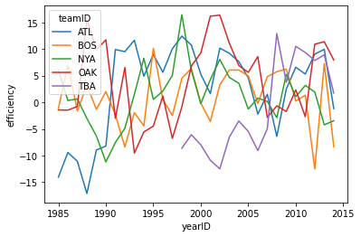

```python
sns.lineplot(data = new_table[filters], x = "yearID", y = "efficiency", hue = 'teamID')
```

```python
# QUESTION 4

# I notice that OAK has been the most successful with their efficiency out of all the teams during MoneyBall period.
# This graph compared to the other graphs can show me how much the team's effieciencies have fluctuated throughout the years. I can better see their movement and changes they've made
```